# Color

Bienvenidos a la sessión. En esta oportunidad usted explorará las opciones con color en el sistema básico de graficar en R. Cuando digo en R, espero que usted esté trabajando en RStudio siempre para este curso.

Antes de empezar, usted necesita ejecutar este código para cargar algunos elementos en su sesión.

```r
require(swirl)

.pathtofile <<- function(course_, lesson_, file_){
  if(as.character(packageVersion("swirl")) > "2.2.21"){
    file.path(get_swirl_option("courses_dir"), course_, lesson_, file_)
  } else {
    file.path(find.package("swirl"), "Courses", course_, lesson_, file_)
  }
}

# Make path to csv available to user
path2csv2 <- file.path(path.package('swirl'), 'Courses',
                       'ConoceR',
                       'Graficando_3_con_2_variables',
                       'hijosDetalle.csv')

detalle <- read.csv(path2csv2)
```

Ya que usted conoce a R, no le va a sorprender que hay muchas maneras de trabajar con color, y incluso unos paquetes con paladares alternativos. Nos quedamos con los básicos en esta sessión.

R tiene nombrado 657 colores, y se puede llamar a ellos por su nombre, o varias codificaciones de color como hexadecimal o RGB valores. Para ver la lista de los colores, teclee colors(). Dese la oportunidad ahora.

```r
head(colors())
```

```
## [1] "white"         "aliceblue"     "antiquewhite"  "antiquewhite1"
## [5] "antiquewhite2" "antiquewhite3"
```

En la ventanilla de PLOTS hubiera aparecido, o empezado de aparecer, una representacíon de los 657 colores ordenados por tonalidad, saturación, y valor.

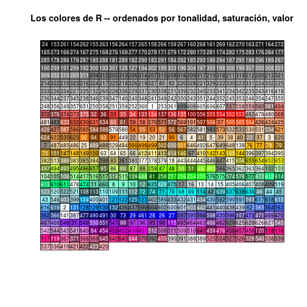

Esta tabla se cita mucho en las fuentes en linea de R. Usted puede consultarla, y otras configuraciones útiles, en esa página http://research.stowers-institute.org/efg/R/Color/Chart/index.htm. Si usted encuentra un recurso semejante en castellano, ¡compártalo con nosotros por el foro!

Muy bien, ¿pero como le va a ayudar esto? Pues, con el código numérico que se ve en la tabla de colores, se puede llamar al nombre del color en su gráfica. A mi me llama la atención el color número 642, así vamos a conocerlo. Ya hemos visto que el objeto que almacena los colores se llama colors(), ¿verdad? Pues a este comando vamos a especificar el número del color que queremos destacar en corchetes cuadrados [], así colors()[642]. Inténtelo.

```r
colors()[642]
```

```
## [1] "violetred1"
```

Aunque le parezca un poco torpe, este comando pide el color con índice 642 de todos los colores.

OK, ahora ustd va a llamar este color para reconstruir la gráfica que vimos en el vídeo de las opiniones de la gente de Bogotá sobre sus vidas. Las primeras cifras de la gráfica superior fueron 51 % en 2011 quienes creyeron que su nivel de vida ha mejorado en los 5 años anteriores, comparado con 54.2% en 2014.

Primero con el color que sale por defecto, proporcione usted los siguientes argumentos a la función barplot(). Primero tiene que especificar la altura (height) de las barras así height=c(51, 54.2), y luego un argumento para los nombres (etiquetas) de las barras, así names.arg=c('2011', '2014'). Envuelve los dos argumentos en la función barplot(), seperados por una coma, para empezar.

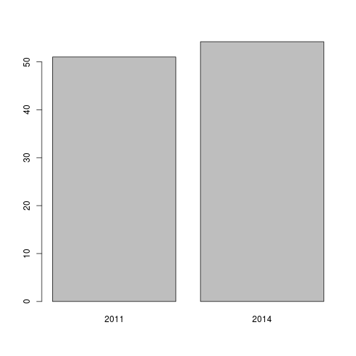

```r
barplot(height = c(51, 54.2), names.arg = c('2011', '2014'))
```

Usted va a añadir ese color 'violetred1' entonces. Como hicieron ellos de la oficina del alcalde de Bogotá, queremos que sobresale 2014, así que dejarémos 2011 en gris. Recupere el comando anterior y despues de una coma, modifique la llamada a barplot() con el siguiente col = c('grey', 'violetred1').

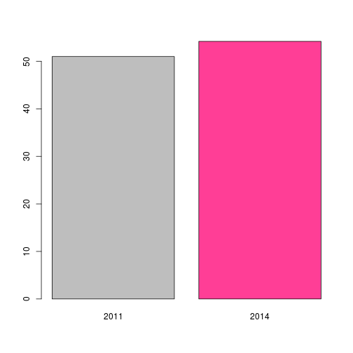

```r
barplot(height = c(51, 54.2), names.arg = c("2011", "2014"),
  col = c("grey", "violetred1"))
```

En este momento podríamos reproducir el efecto del corte del eje que hicieron ellos de la oficina del alcalde. ¿Se acuerde que tan fuerte parecía la diferencia entre 2011 y 2014 en su gráfica? Se lo hace por introducir otro argumento ylim = c(49, 55) - ya que estos fueron los limites de su versión de la gráfica, pero también tenemos que ingresar otra argumento xpd=FALSE. Inténtelo usted, recupere el último comando otra vez y añádale los dos argumentos mencionados.

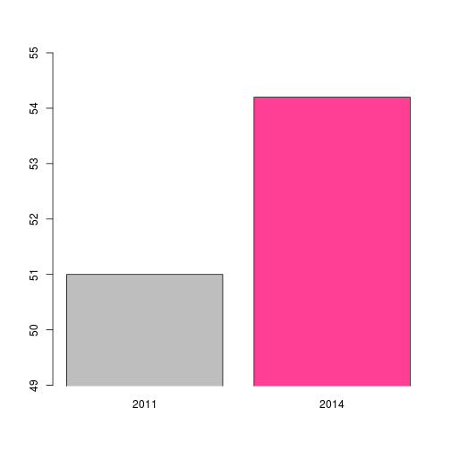

```r
barplot(height = c(51, 54.2), names.arg = c("2011", "2014"),
  col = c("grey", "violetred1"), ylim = c(49,55), xpd = FALSE)
```

¡Vaya cambiazo, verdad! Esta versión es más llamativa, pero no es una buena practica, así vamos a quitar los últimos dos argumentos con los cual cambiara el eje Y. Lo que si usted debe introducir en el comando son las etiquetas para los ejes. En este paso usted debe quitar los argumentos a ylim y xpd, y añadir ylab='porcentage de encuestados' y xlab = 'Año de la encuesta'.“

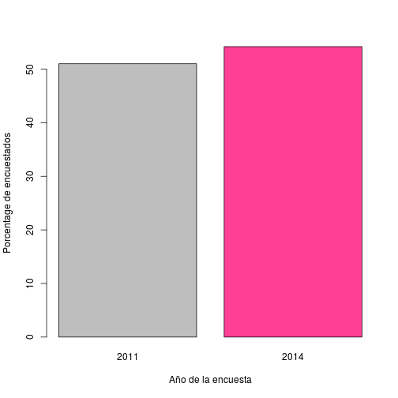

```r
barplot(height = c(51, 54.2), names.arg = c('2011', '2014'),
  col = c('grey', 'violetred1'),
  ylab='Porcentage de encuestados',
  xlab='Año de la encuesta')
```

Bueno, le desvié un poco con esto de la escala del eje Y, regresamos al tema de color. A propósito, si a usted le gustaría destacar diferencias pequeñas como vemos en este ejemplo, toca seleccionar un gráfico de puntos.

De hecho, hay una manera aún más sencillo para introducir un juego limitado de colores dentro de gráficas. R tiene un paladar de 8 colores que se puede llamar por el número. Usted los hubiera visto en el vídeo en la gráfica bien fea mía. Se los puede ver por teclear el siguiente barplot(1:8, col=1:8).

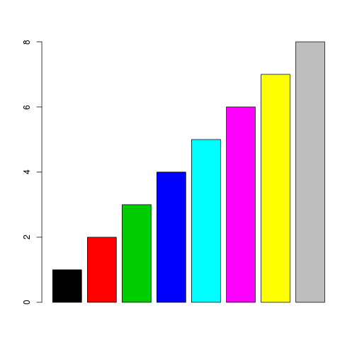

```r
barplot(1:8, col=1:8)
```

A propósito, algunos de los expertos en visualización opinan diferente en la cuestión de cuál color es más fiable cuando le toca añadir color para destacar algo. En sus libros Edward Tufte propone rojo, pero ayer vi un autor opinando que para pantallas y fuentes del internet, azul suele ser la mejor opción. Yo no tengo opiniones fuertes en este asunto, aunque supongo en mi práctica voy con rojo. Rojo se llama con col=2, y azul con col=4.

Ojo - estos numeros no tienen nada que ver con los índices de los colores en la tabla completa de colores que usted vio antes. Por ejemplo el índice para blanco en la tabla completa era 1, así que lo llamara por col=colors()[1], mientras que 1 en esta serie limitada de colores llama al color negro, y con el sintaxis col=1.

Una aplicación super útil en R es asignar color por una variable de agrupación o factor. En el fondo le hemos cargado un conjunto 'detalle' que lleva los datos del número promedio de hijos y hijas que tenían las ecuatorianas según el censo de 2010. Confirme que está vigente en la sessión con head(detalle).

En este paso usted va a graficar todos los valores en el conjunto, pero especificar que el color siga la variable area. Area es la variable que cuenta si la encuestada pertencía de una zona urbana o rural. Así se hace with(detalle, plot(hijos, col = area)). Dese la oportunidad.

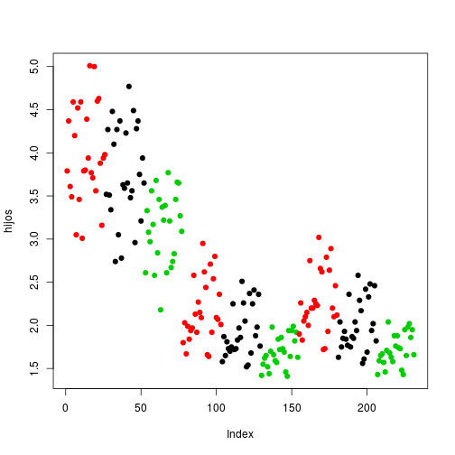

```r
with(detalle, plot(hijos, col = area, pch=19))
```

Para entender esta vista de los datos, hay que acordarse que en este conjunto tenemos datos promedios por cada provinicia de El Ecuador, y luego desglosados por alfabetización y la zona, rural o urbana.

# Anotaciones

¿Le parece que añadimos unas anotaciones a esta gráfica? Empezamos con unas palabras. Todos las gráficas y por lo tanto lo que podemos añadir como anotaciones necesita información sobre las coordinadas de forma precisa o, bajo ciertas condiciones, vaga. Añada las palabras ¿cuál color va con cuál nivel de área?. Este texto va entre comillas con el argumento labels=''. También, usted tiene que especificar un lugar. Digamos que x sea 150, e y sea 4. Ensamblar estos detalles dentro la función text() ahora en el indicador de RStudio.

```r
text(x=150, y=4, labels='¿cuál color va con cuál nivel de área?')
```

[output not shown]

Si usted quiere romper lineas en el texto, hay que ingresar la combinación ”\n" en el lugar donde quiere que divide el texto. Le sugierso que experimenta con las opciones de más del función text(), los cuales brindan un nivel de contro muy fino.

Usted reconocerá que algunos técnicas, como lo de añadir texto, podrían hacerse con igual o mayor facilidad en un programa de terceros. Sin embargo, no hace daño aprenderlas en R.

Si usted quisiera añadir una linea para destacar algún umbral en la gràfica, hay varias opciones. Se puede utilizar la función abline() cuya nombre quiere decir trace una linea entre a y b. Imagínese que queremos isladar el primer tercio (más o menos) del espacio, donde hay las mujeres que no sabían leer ni escribir. La función abline() tiene hace más cosas, pero ahora solo queremos pedir que nos añade una linea vertical alrededor de donde 77 en el eje X. Teclee abline(v=77) entonces, para una linea v para vertical.

```r
abline(v=77)
```

[output not shown]

Super sencillo verdad? Para lineas horizontales haríamos algo muy parecido, aunque con h en lugar de v.

Para especificar una linea que empieza y termina donde usted quiera, utilzamos segments(). Esta función require más argumentos, porque tenemos que proporcionar las coordinadas en las dimensiones x y y. Sería más facíl entender con un ejemplo. Digamos que quiero trazar una linea que empieza en nuestra recta vertical en 77 y va en el plano horizontal hasta 200 en la altura que cabiera los datos de las alfabetizadas, y los datos para alfabetizadas y no alfabetizadas juntas. Lo voy a hacer mas gruesa también con lwd=. La receta es así segments(x0= 77, x1=200, y0 = 3.2, y1 = 3.2, lwd=2)

```r
segments(x0= 77, x1=200, y0 = 3.2, y1 = 3.2, lwd=2)
```

[output not shown]

Ya se hubiera dado cuenta que con esta función puede dibujar una linea entre cualquier par de puntos en el espacio que establece el cuadro.

Desde luego, le he hecho crear un pequeño disastre acá, metiendo estos elementos sin razón. Sin embargo, la idea es que usted aprenderá la técnica y lugeo la puede aplicar en un contexto donde tiene sentido. Siguemos, ¿no? Para flechas, los argumentos son parecidos a los de segments, aunque tenemos que meter unos más para la forma del punto de la flecha. Pruebe esto arrows(x0= 77, x1=200, y0 = 3.2, y1 = 3.2, lwd=2, length = 0.5)

```r
arrows(x0= 77, x1=200, y0 = 3.2, y1 = 3.2, lwd=2, length = 0.5)
```

[output not shown]

Lo que usted necesita más que nada es practicar. Le animo practicar en un espiritu de diversión y aventura. Si no le sale algo, inténtelo de otra manera, o escriba en el foro sobre su inconveniente. Con el R, siempre hay varias maneras de lograr cualquier cosa, y el internet es una fuente muy rica de buen consejos y ejemplos hechos.

Note que muchos de los ejemplos dentro de estas lecciones no llevan los elementos imprescindibles de etiquetas para los ejes con unidades de medida, títulos, etcétera. Lo hacemos así para enfocarle en lo nuevo de la lección, y para que los comandos sean más ligeros. Sin embargo, sus obras siempre deben llevar estos elementos. Pues, seguro que le he quedado con dudas, pero ¡por eso tenemos el foro! Nos vemos allí.